Home

# Human Activity Recognition (HAR)

In this project we will be using the sensor data recorded using a smartphone. The [HAR dataset](https://www.kaggle.com/uciml/human-activity-recognition-with-smartphones) provides various measurements of the Activities of Daily Living (ADL) of 30 subjects. It consists of various sensor measurements of people, while they are performing activities like standing, walking, sitting, lying down etc. Such a dataset is a mine of information, providing insights into the movement related aspects of individuals. For example, one person's speed of walking is different from another. It stands to reason that a person's physical condition can be correlated to his/her walking speed. This is just one example, we will look into more interesting questions.

We will address the following questions.

1. Can we accurately predict the activity of a person using this dataset? If so, then which is the best model?
2. Which attributes are the most vital ones for predicting the activity of a person?

First, let's import the required library.

```python
from jupyterthemes import jtplot

jtplot.style()
```

```python
import pandas as pd
```

Now let's see the names of the files we are going to be working with.

```python
import os
for dirname, _, filenames in os.walk('/kaggle/input'):
    for filename in filenames:
        print(os.path.join(dirname, filename))
```

```
/kaggle/input/human-activity-recognition-with-smartphones/train.csv
/kaggle/input/human-activity-recognition-with-smartphones/test.csv
```

Load the training data.

```python
train_data = pd.read_csv('../input/human-activity-recognition-with-smartphones/train.csv')
```

```python
test_data = pd.read_csv('../input/human-activity-recognition-with-smartphones/test.csv')
```

## Exploring the dataset

Let's see the columns in the training set and understand what they mean.

The description of the dataset has the following: For each record in the dataset the following is provided:

- Triaxial acceleration from the accelerometer (total acceleration) and the estimated body acceleration.
- Triaxial Angular velocity from the gyroscope.
- Its activity label.
- An identifier of the subject who carried out the experiment.

```python
train_data.shape
```

```
(7352, 563)
```

```python
train_data.head()
```

|  | tBodyAcc-mean()-X | tBodyAcc-mean()-Y | tBodyAcc-mean()-Z | tBodyAcc-std()-X | tBodyAcc-std()-Y | tBodyAcc-std()-Z | tBodyAcc-mad()-X | tBodyAcc-mad()-Y | tBodyAcc-mad()-Z | tBodyAcc-max()-X | ... | fBodyBodyGyroJerkMag-kurtosis() | angle(tBodyAccMean,gravity) | angle(tBodyAccJerkMean),gravityMean) | angle(tBodyGyroMean,gravityMean) | angle(tBodyGyroJerkMean,gravityMean) | angle(X,gravityMean) | angle(Y,gravityMean) | angle(Z,gravityMean) | subject | Activity |
| --- | --- | --- | --- | --- | --- | --- | --- | --- | --- | --- | --- | --- | --- | --- | --- | --- | --- | --- | --- | --- | --- |
| 0 | 0.288585 | -0.020294 | -0.132905 | -0.995279 | -0.983111 | -0.913526 | -0.995112 | -0.983185 | -0.923527 | -0.934724 | ... | -0.710304 | -0.112754 | 0.030400 | -0.464761 | -0.018446 | -0.841247 | 0.179941 | -0.058627 | 1 | STANDING |
| 1 | 0.278419 | -0.016411 | -0.123520 | -0.998245 | -0.975300 | -0.960322 | -0.998807 | -0.974914 | -0.957686 | -0.943068 | ... | -0.861499 | 0.053477 | -0.007435 | -0.732626 | 0.703511 | -0.844788 | 0.180289 | -0.054317 | 1 | STANDING |
| 2 | 0.279653 | -0.019467 | -0.113462 | -0.995380 | -0.967187 | -0.978944 | -0.996520 | -0.963668 | -0.977469 | -0.938692 | ... | -0.760104 | -0.118559 | 0.177899 | 0.100699 | 0.808529 | -0.848933 | 0.180637 | -0.049118 | 1 | STANDING |
| 3 | 0.279174 | -0.026201 | -0.123283 | -0.996091 | -0.983403 | -0.990675 | -0.997099 | -0.982750 | -0.989302 | -0.938692 | ... | -0.482845 | -0.036788 | -0.012892 | 0.640011 | -0.485366 | -0.848649 | 0.181935 | -0.047663 | 1 | STANDING |
| 4 | 0.276629 | -0.016570 | -0.115362 | -0.998139 | -0.980817 | -0.990482 | -0.998321 | -0.979672 | -0.990441 | -0.942469 | ... | -0.699205 | 0.123320 | 0.122542 | 0.693578 | -0.615971 | -0.847865 | 0.185151 | -0.043892 | 1 | STANDING |

5 rows × 563 columns

```python
train_data.isna().sum().sum()
```

```
0
```

## Checking for imbalance in the labeled instances

Let's see how many instances of each label there is in the dataset.

```python
train_data.Activity.value_counts()
```

```
LAYING                1407
STANDING              1374
SITTING               1286
WALKING               1226
WALKING_UPSTAIRS      1073
WALKING_DOWNSTAIRS     986
Name: Activity, dtype: int64
```

```python
import seaborn as sns
import matplotlib.pyplot as plt
```

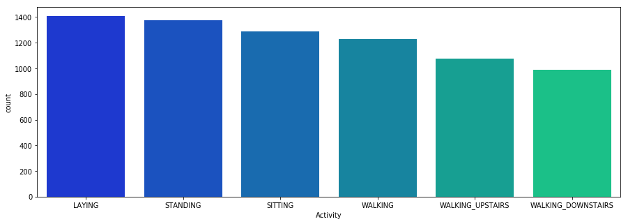

```python
fig = plt.figure(figsize = (15, 5))
sns.countplot(x = 'Activity',
              data = train_data,
              #palette = "Blues_r",
              palette = 'winter',
              order = train_data['Activity'].value_counts().index
             )
```

The dataset does not have much of an imbalance in the classes.

## Distribution of attributes

It is important that we understand the distribution of the values in all the columns of our data, but as we have noticed, there are too many attributes (561 of them!). Surely, we cannot examine all of them. So, what shall we do?

```python
# Plots distribution of 6 columns

def plot_distribution(data, col):
    fig, axes = plt.subplots(ncols = 3, nrows = 2, figsize = (15, 8))
    for i, ax in zip(range(6), axes.flat):
        sns.distplot(data[cols[i]], ax = ax)
    plt.show()
```

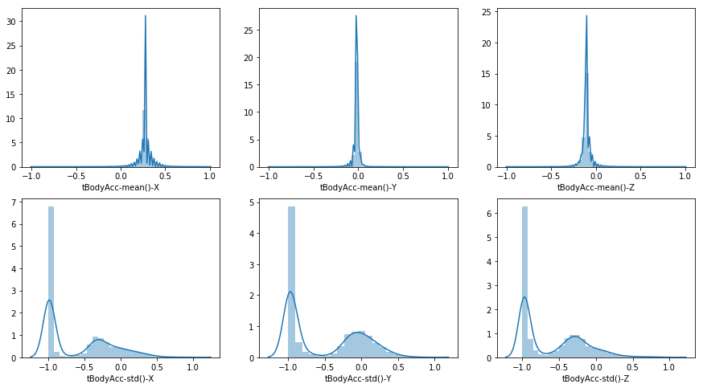

```python
# Select some body acceleration attributes
cols = train_data.columns[:6]
plot_distribution(train_data, cols)
```

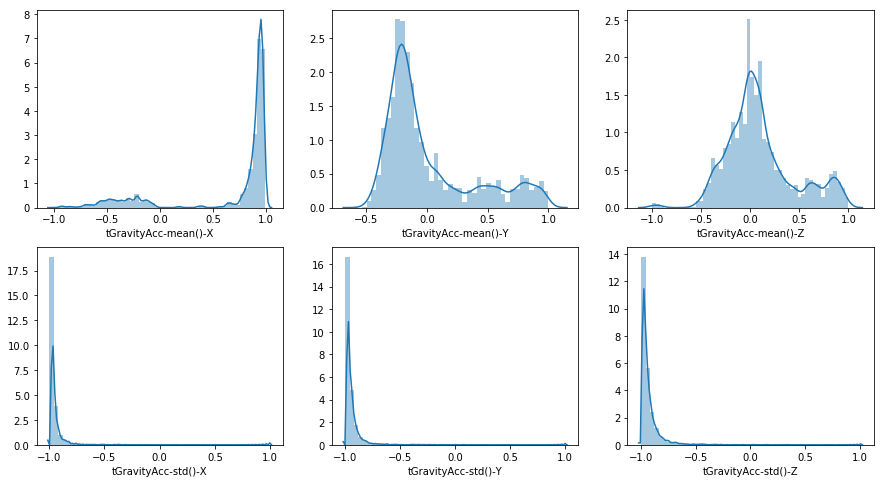

```python
# Select some gravitational acceleration attributes
cols = train_data.columns[40:47]
plot_distribution(train_data, cols)
```

Some of the attributes are not nearly normally distributed. We observe skew in several gravitational acceleration measurements.

## Visualizing the dataset

In order to get good results, the instances belonging to different labels must be seperable. We will use t-distibuted Stocastic Neighbor Embedding (t-SNE) to visualize the data.

```python
from sklearn.manifold import TSNE
```

We will make a copy of the train data before applying t-SNE. We will also extract the labels from the data and store it seperately.

```python
tsne_data = train_data.copy()
tsne_data.drop(['Activity', 'subject'], axis = 1, inplace = True)
```

Get the counts of each activity.

```python
labels = train_data['Activity']
label_counts = labels.value_counts()
```

Standardization is done on the data prior to applying t-SNE. This is done in order to make the data look almost normally distributed.

```python
from sklearn.preprocessing import StandardScaler
```

```python
def scale_data(data):
    scl = StandardScaler()
    return scl, scl.fit_transform(data)
```

```python
scale_model, scaled_data = scale_data(tsne_data)
scaled_data.shape
```

```
(7352, 561)
```

Now we will apply t-SNE on the scaled train data.

```python
tsne = TSNE(random_state = 0)
tsne_transformed = tsne.fit_transform(scaled_data)
```

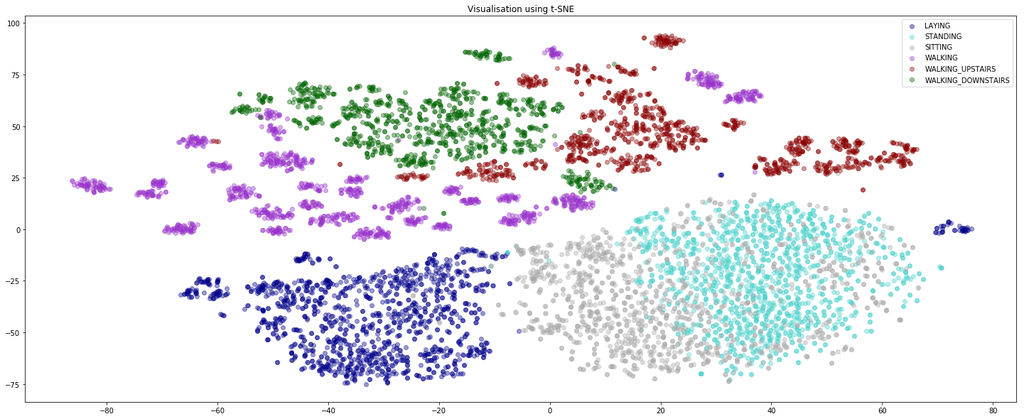

```python
fig1 = plt.figure(figsize = (25, 10))
colors = ['darkblue', 'mediumturquoise', 'darkgray', 'darkorchid', 'darkred', 'darkgreen']
for i, activity in enumerate(label_counts.index):
    mask = (labels == activity).values
    plt.scatter(x = tsne_transformed[mask][:,0],
                y = tsne_transformed[mask][:,1],
                color = colors[i],
                alpha = 0.4,
                label = activity)
plt.title('Visualisation using t-SNE')
plt.legend()
plt.show()
```

## 1. Can we accurately predict the activity of a person using this dataset? If so, then which is the best model?

### Creating prediction model

We will try the simple decision tree classifier first.

```python
from sklearn.metrics import classification_report
from sklearn.metrics import accuracy_score
import numpy as np
```

```python
X_train = train_data.drop(['Activity', 'subject'], axis = 1)
y_train = train_data['Activity']

X_test = test_data.drop(['Activity', 'subject'], axis = 1)
y_test = test_data['Activity']
```

```python
from sklearn.tree import DecisionTreeClassifier

clf_dt = DecisionTreeClassifier(max_depth = 30)
```

```python
clf_dt.fit(X_train, y_train)
```

```
DecisionTreeClassifier(class_weight=None, criterion='gini', max_depth=30,
                       max_features=None, max_leaf_nodes=None,
                       min_impurity_decrease=0.0, min_impurity_split=None,
                       min_samples_leaf=1, min_samples_split=2,
                       min_weight_fraction_leaf=0.0, presort=False,
                       random_state=None, splitter='best')
```

```python
y_train_pred_dt = clf_dt.predict(X_train)
```

```python
y_test_pred_dt = clf_dt.predict(X_test)
```

```python
def plot_train_test_accuracy(y_train, y_train_pred, y_test, y_test_pred, title):
    acc_train = accuracy_score(y_train, y_train_pred)
    acc_test = accuracy_score(y_test, y_test_pred)

    print('Train accuracy = ', acc_train)
    print('Test accuracy = ', acc_test)

    ax = plt.figure()
    plt.bar(x = 'train accuracy', height = acc_train, color='darkblue')
    plt.bar(x = 'test accuracy', height = acc_test, color='lightblue')
    plt.xticks(['train accuracy', 'test accuracy'])
    plt.title(title)
```

```
Train accuracy =  1.0
Test accuracy =  0.8523922633186292
```

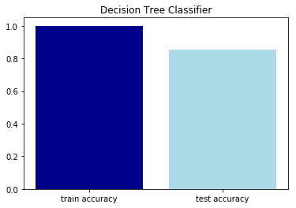

```python
plot_train_test_accuracy(y_train, y_train_pred_dt, y_test, y_test_pred_dt, 'Decision Tree Classifier')
```

By examining the above figure it can be noticed that there is some amout of overfitting going on. Bagging is well-known method for reducing variance of a model.

### Bagging

Random Forest Classifier is an ensemble learning technique used to reduce the variance of a base learning algorithm (in our case the Decision Tree classifier).

```python
from sklearn.ensemble import RandomForestClassifier
```

```python
clf_rf = RandomForestClassifier(n_estimators = 100)
```

```python
clf_rf.fit(X_train, y_train)
```

```
RandomForestClassifier(bootstrap=True, class_weight=None, criterion='gini',
                       max_depth=None, max_features='auto', max_leaf_nodes=None,
                       min_impurity_decrease=0.0, min_impurity_split=None,
                       min_samples_leaf=1, min_samples_split=2,
                       min_weight_fraction_leaf=0.0, n_estimators=100,
                       n_jobs=None, oob_score=False, random_state=None,
                       verbose=0, warm_start=False)
```

```python
y_train_pred_rf = clf_rf.predict(X_train)
```

```python
y_test_pred_rf = clf_rf.predict(X_test)
```

```
Train accuracy =  1.0
Test accuracy =  0.9284017645062775
```

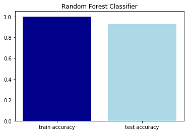

```python
plot_train_test_accuracy(y_train, y_train_pred_rf, y_test, y_test_pred_rf, 'Random Forest Classifier')
```

The accuracy on test set has been improved!

### Gradient Boosting

Next we will try gradient boosting based tree classifier. The base learner will be a weak classifier such as a Decision Tree with maximum depth 3.

```python
from lightgbm import LGBMClassifier

lgbm = LGBMClassifier(max_depth = 3, n_estimators = 500, random_state = 0)
lgbm.fit(X_train, y_train)
```

```
LGBMClassifier(boosting_type='gbdt', class_weight=None, colsample_bytree=1.0,
               importance_type='split', learning_rate=0.1, max_depth=3,
               min_child_samples=20, min_child_weight=0.001, min_split_gain=0.0,
               n_estimators=500, n_jobs=-1, num_leaves=31, objective=None,
               random_state=0, reg_alpha=0.0, reg_lambda=0.0, silent=True,
               subsample=1.0, subsample_for_bin=200000, subsample_freq=0)
```

```python
y_train_pred_lgbm = lgbm.predict(X_train)
y_test_pred_lgbm = lgbm.predict(X_test)
```

```
Train accuracy =  1.0
Test accuracy =  0.9497794367153037
```

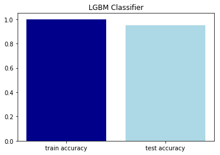

```python
plot_train_test_accuracy(y_train, y_train_pred_lgbm, y_test, y_test_pred_lgbm, 'LGBM Classifier')
```

## 2. Which attributes are the most vital ones for predicting the activity of a person?

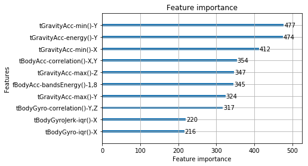

```python
from lightgbm import plot_importance
plot_importance(lgbm, max_num_features = 10)
plt.show()
```